# miR-375 KO (baseline)

Part1: Ambient RNA removal

## Sample description

This is the single cell RNAseq data of two 375KO mice and two WT mice (generated by 10X Genomics Chromium platform - 3’ V2 kit). Samples were jejunal crypts isolated from sex and age matched 375KO and WT mice (male; 12m old; chow diet condition).

## Load required libraries

```r
library(Seurat, lib.loc = "/programs/R-4.0.5/library")
library(tidyverse, lib.loc = "/programs/R-4.0.5/library")
library(SoupX)
#library(DropletUtils, lib.loc = "/home/yah6/R/x86_64-pc-linux-gnu-library/4.0")
```

## Demultiplexing

The demultiplexing of these samples was done by Cornell core.

## Alignment and quantification

Alignment and quantification of single cell data is done using cellranger count from the 10X genomics cellranger software package.

Cellranger count performs alignment, filtering, barcode counting, and UMI counting. It uses the Chromium cellular barcodes to generate feature-barcode matrices, determine clusters, and perform gene expression analysis.

Expanding on the general overview, demultiplexed fastqs are aligned to the genome using STAR. Reads aligning to the transcriptome are grouped by barcode, UMI, and associated gene. If the same barcode and UMI are associated with mulitple genes, the more supported gene group is kept and the other is discarded. After filtering, each barcode-UMI-gene is recorded as a single UMI count in the barcode-feature matrix. Next, cellranger calls cells based on the EmptyDrops method from Lun et al., 2018. This first calls high UMI content barcodes as cells. Secondly, it constructs a background model of the lowliest UMI-containing barcodes (empty droplets) and compares the profile of the remaining uncalled barcodes to the model. Barcodes poorly fittiing the background model are called as cells.

More information on cellranger can be found here: https://support.10xgenomics.com/single-cell-gene-expression/software/overview/welcome

More information on the underlying cellranger algorithms can be found here: https://support.10xgenomics.com/single-cell-gene-expression/software/pipelines/latest/algorithms/overview

The cellranger count commands are based on the Broad Core command and is as follows:

```r
### 375KO sample

#!/bin/bash
# KO from set 1
/programs/cellranger-3.0.1/cellranger count \
--id=KO-12m_v2 \
--sample=108168_H7YCKBGXC_2_KO \
--localcores=22 \
--fastqs=H2Y5TBGXB_Sethupathy_10414279_cellranger_mkfastq_output_20April19/outs/fastq_path/ \
--transcriptome=/home/pr46_0001/projects/genome/refdata-cellranger-mm10-1.2.0

# KO from set 2
/programs/cellranger-3.0.1/cellranger count \
--id=375KO_KO_2019oct \
--sample=95294_H2Y5TBGXB_KO \
--localcores=22 \
--fastqs=H7YCKBGXC_Singh_10422070_cellranger_mkfastq_output_15Oct19/outs/fastq_path/ \
--transcriptome=/home/pr46_0001/projects/genome/refdata-cellranger-mm10-1.2.0

### WT sample

#!/bin/bash
# WT from set 1
/programs/cellranger-3.0.1/cellranger count \
--id=WT-12m_v2 \
--sample=95294_H2Y5TBGXB_WT \
--localcores=22 \
--fastqs=H2Y5TBGXB_Sethupathy_10414279_cellranger_mkfastq_output_20April19/outs/fastq_path/ \
--transcriptome=/home/pr46_0001/projects/genome/refdata-cellranger-mm10-1.2.0

# WT from set 2
/programs/cellranger-3.0.1/cellranger count \
--id=375KO_WT_2019oct \
--sample=108167_H7YCKBGXC_1_WT \
--localcores=22 \
--fastqs=H7YCKBGXC_Singh_10422070_cellranger_mkfastq_output_15Oct19/outs/fastq_path/ \
--transcriptome=/home/pr46_0001/projects/genome/refdata-cellranger-mm10-1.2.0
```

Logs from these runs can be found on the Cornell HPC in the following directory: `/home/pr46_0001/scRNAseq/2019_10_375KO_12m/` and `/home/pr46_0001/scRNAseq/2019_04_375KO_12m/`.

## Removal of ambient RNA using SoupX - function

In single cell experiments, non-endogenous RNA can make up anywhere from 2-50% of all counts, although 10% seems like a decent expectation. To remove these exogenous counts, we can use the SoupX program that models the background expression from empty droplets. More information can be found in the [SoupX manuscript](https://academic.oup.com/gigascience/article/9/12/giaa151/6049831) or the [SoupX tutorial](https://rawcdn.githack.com/constantAmateur/SoupX/204b602418df12e9fdb4b68775a8b486c6504fe4/inst/doc/pbmcTutorial.html). I further took the advice of this [CellGen vignette](https://cellgeni.github.io/notebooks/html/new-10kPBMC-SoupX.html) to use the Seurat clustering. Other options for ambient RNA removal include Cell Bender, DecontX, and SoupOrCell.

```r
# Since we will be repeating SoupX on each of our 4 samples, I'll combine the code into a function
#
# The matrix files are output by cellranger
#     filtered = only has droplets with putative cell
#     raw = containts all droplets, both putative cells and empty droplets

SoupX.f <- function(raw.matrix, filtered.matrix) {
  # Create soup channel with the raw and filtered matrix
  soup.channel  <- SoupChannel(raw.matrix, filtered.matrix)
  print(soup.channel)

  # SoupX requires clusters in order to define marker genes. One can either use CellRanger clustering or quickly cluster using Seurat.
  # I chose to use Seurat here.

  seurat_obj <- CreateSeuratObject(counts = filtered.matrix)
  seurat_obj    <- SCTransform(seurat_obj, verbose = F)
  seurat_obj    <- RunPCA(seurat_obj, verbose = F)
  seurat_obj    <- RunUMAP(seurat_obj, dims = 1:30, verbose = F)
  seurat_obj    <- FindNeighbors(seurat_obj, dims = 1:30, verbose = F)
  seurat_obj    <- FindClusters(seurat_obj, verbose = T)

  # The cluster information from Seurat can be fed into the SoupX setClusters function
  meta <- seurat_obj@meta.data
  umap <- seurat_obj@reductions$umap@cell.embeddings
  soup.channel <- setClusters(soup.channel, setNames(meta$seurat_clusters, rownames(meta)))
  soup.channel <- setDR(soup.channel, umap)

  # After defining the clusters, we can run calculate the ambient RNA profile
  soup.channel <- autoEstCont(soup.channel)
  print(head(soup.channel$soupProfile[order(soup.channel$soupProfile$est, decreasing = T), ], n = 20))

  # We can adjust the counts and save the new count matrix
  adj.matrix <- adjustCounts(soup.channel, roundToInt = T)
  return(adj.matrix)
}
```

## Removal of ambient RNA with SoupX

### KO set 1

```r
filtered.matrix <- Read10X_h5("/home/pr46_0001/scRNAseq/2019_04_375KO_12m/KO-12m_v2/outs/filtered_gene_bc_matrices_h5.h5",use.names = T)
raw.matrix <- Read10X_h5("/home/pr46_0001/scRNAseq/2019_04_375KO_12m/KO-12m_v2/outs/raw_gene_bc_matrices_h5.h5",use.names = T)
adj.counts <- SoupX.f(raw.matrix, filtered.matrix)
```

```
## Channel with 27998 genes and 1251 cells
```

```
## Modularity Optimizer version 1.3.0 by Ludo Waltman and Nees Jan van Eck
##
## Number of nodes: 1251
## Number of edges: 37618
##
## Running Louvain algorithm...
## Maximum modularity in 10 random starts: 0.8153
## Number of communities: 10
## Elapsed time: 0 seconds
```

```
## 1068 genes passed tf-idf cut-off and 102 soup quantile filter.  Taking the top 100.
```

```
## Using 724 independent estimates of rho.
```

```
## Estimated global rho of 0.04
```

```
##                  est counts
## Defa24   0.063813860 255225
## mt-Atp6  0.025128497 100502
## mt-Co3   0.023867346  95458
## Gm15284  0.017547593  70182
## mt-Nd1   0.012285215  49135
## mt-Cytb  0.012157200  48623
## Lyz1     0.011660391  46636
## mt-Co1   0.010779535  43113
## mt-Co2   0.010597764  42386
## Tff3     0.008411253  33641
## Defa20   0.008304740  33215
## Defa22   0.008205228  32817
## Defa21   0.008030208  32117
## AY761184 0.007831684  31323
## Zg16     0.007417134  29665
## mt-Nd4   0.006924326  27694
## Fabp2    0.005877451  23507
## Lgals2   0.005533910  22133
## Tmsb4x   0.005404645  21616
## Gm14851  0.005264128  21054
```

```
## Expanding counts from 10 clusters to 1251 cells.
```

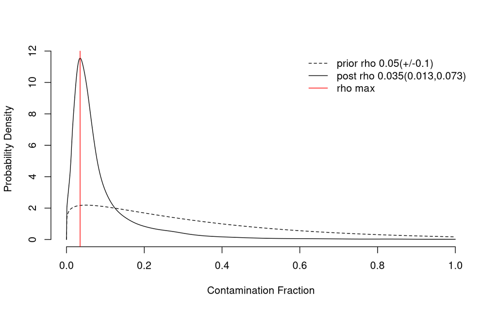

```r
# write output (generated already)
#DropletUtils:::write10xCounts("/workdir/yah6/soupx_KO_filt", adj.counts, overwrite = T)
```

### KO set 2

```r
filtered.matrix <- Read10X_h5("/home/pr46_0001/scRNAseq/2019_10_375KO_12m/375KO_KO_2019oct/outs/filtered_feature_bc_matrix.h5",use.names = T)
raw.matrix <- Read10X_h5("/home/pr46_0001/scRNAseq/2019_10_375KO_12m/375KO_KO_2019oct/outs/raw_feature_bc_matrix.h5",use.names = T)
adj.counts <- SoupX.f(raw.matrix, filtered.matrix)
```

```
## Channel with 27998 genes and 7665 cells
```

```
## Modularity Optimizer version 1.3.0 by Ludo Waltman and Nees Jan van Eck
##
## Number of nodes: 7665
## Number of edges: 273595
##
## Running Louvain algorithm...
## Maximum modularity in 10 random starts: 0.8823
## Number of communities: 24
## Elapsed time: 1 seconds
```

```
## 4353 genes passed tf-idf cut-off and 1721 soup quantile filter.  Taking the top 100.
```

```
## Using 1397 independent estimates of rho.
```

```
## Estimated global rho of 0.03
```

```
##                  est counts
## mt-Atp6  0.089190945 122987
## mt-Co3   0.089027049 122761
## mt-Co2   0.060847708  83904
## mt-Co1   0.041131525  56717
## mt-Cytb  0.031471777  43397
## Defa24   0.028241708  38943
## mt-Nd2   0.017734920  24455
## mt-Nd4   0.017146777  23644
## mt-Nd1   0.012300949  16962
## Gm42418  0.010317510  14227
## Lyz1     0.007505885  10350
## Gm15284  0.007297751  10063
## Zg16     0.006841596   9434
## Fabp2    0.006157001   8490
## Fabp1    0.006154101   8486
## AY761184 0.005689969   7846
## Tff3     0.005656609   7800
## Itln1    0.004383147   6044
## mt-Nd3   0.003917564   5402
## Spink4   0.003681147   5076
```

```
## Expanding counts from 24 clusters to 7665 cells.
```

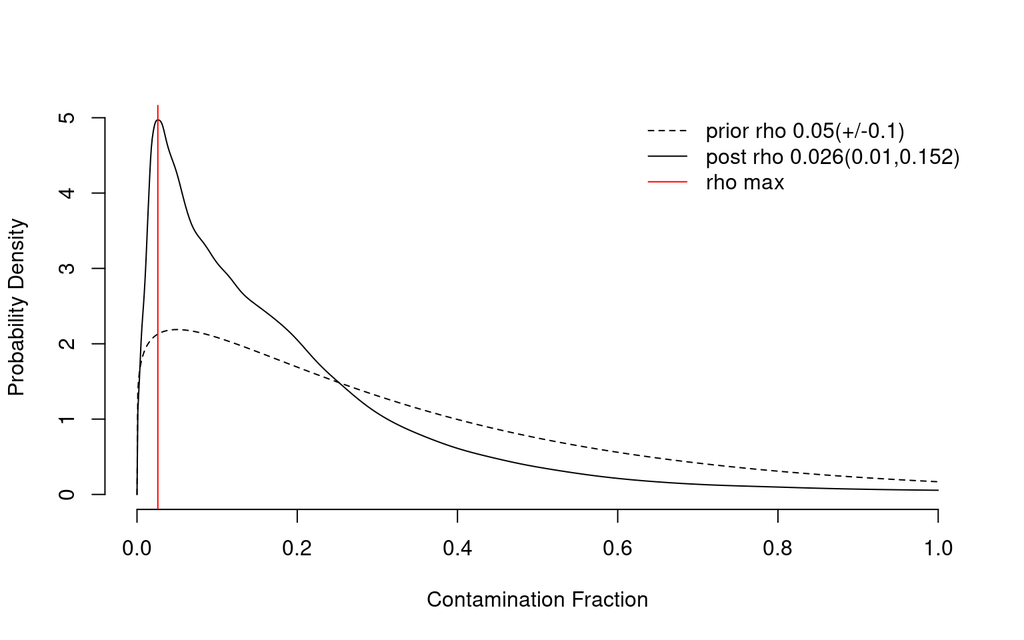

```r
# write output (generated already)
# DropletUtils:::write10xCounts("/workdir/yah6/soupx_KO2_filt", adj.counts, overwrite = T)
```

### WT set 1

```r
filtered.matrix <- Read10X_h5("/home/pr46_0001/scRNAseq/2019_04_375KO_12m/WT-12m_v2/outs/filtered_gene_bc_matrices_h5.h5",use.names = T)
raw.matrix <- Read10X_h5("/home/pr46_0001/scRNAseq/2019_04_375KO_12m/WT-12m_v2/outs/raw_gene_bc_matrices_h5.h5",use.names = T)
adj.counts <- SoupX.f(raw.matrix, filtered.matrix)
```

```
## Channel with 27998 genes and 1209 cells
```

```
## Modularity Optimizer version 1.3.0 by Ludo Waltman and Nees Jan van Eck
##
## Number of nodes: 1209
## Number of edges: 37791
##
## Running Louvain algorithm...
## Maximum modularity in 10 random starts: 0.8116
## Number of communities: 12
## Elapsed time: 0 seconds
```

```
## 1142 genes passed tf-idf cut-off and 78 soup quantile filter.  Taking the top 78.
```

```
## Using 656 independent estimates of rho.
```

```
## Estimated global rho of 0.02
```

```
##                  est counts
## Defa24   0.089524125 416863
## Gm15284  0.022968015 106949
## mt-Atp6  0.016640638  77486
## mt-Co3   0.015346514  71460
## Lyz1     0.014519701  67610
## Defa21   0.013646930  63546
## Defa22   0.013229872  61604
## Defa20   0.012587535  58613
## AY761184 0.012450950  57977
## Gm14851  0.008482890  39500
## mt-Co1   0.007770327  36182
## mt-Cytb  0.007736396  36024
## mt-Nd1   0.007606038  35417
## Fabp2    0.007588213  35334
## mt-Co2   0.007024262  32708
## Tff3     0.006768702  31518
## Defa-rs1 0.006432178  29951
## Eef1a1   0.005306853  24711
## Spink4   0.005217944  24297
## Zg16     0.005042058  23478
```

```
## Expanding counts from 12 clusters to 1209 cells.
```

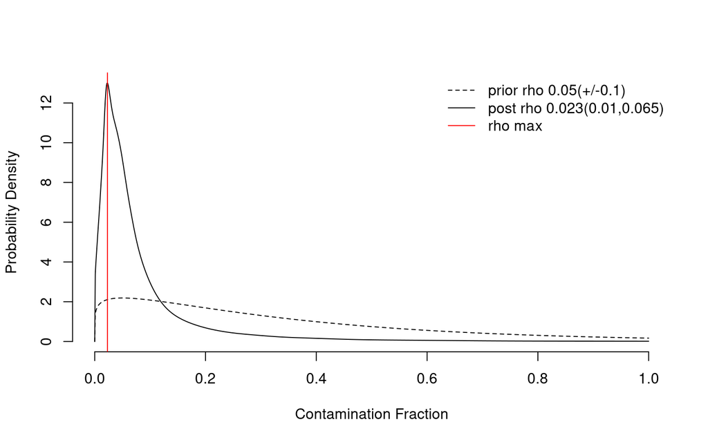

```r
# write output (generated already)
#DropletUtils:::write10xCounts("/workdir/yah6/soupx_WT1_filt", adj.counts, overwrite = T)
```

### WT set 2

```r
filtered.matrix <- Read10X_h5("/home/pr46_0001/scRNAseq/2019_10_375KO_12m/375KO_WT_2019oct/outs/filtered_feature_bc_matrix.h5",use.names = T)
raw.matrix <- Read10X_h5("/home/pr46_0001/scRNAseq/2019_10_375KO_12m/375KO_WT_2019oct/outs/raw_feature_bc_matrix.h5",use.names = T)
adj.counts <- SoupX.f(raw.matrix, filtered.matrix)
```

```
## Channel with 27998 genes and 7711 cells
```

```
## Modularity Optimizer version 1.3.0 by Ludo Waltman and Nees Jan van Eck
##
## Number of nodes: 7711
## Number of edges: 285575
##
## Running Louvain algorithm...
## Maximum modularity in 10 random starts: 0.8819
## Number of communities: 19
## Elapsed time: 1 seconds
```

```
## 6505 genes passed tf-idf cut-off and 2225 soup quantile filter.  Taking the top 100.
```

```
## Using 1177 independent estimates of rho.
```

```
## Estimated global rho of 0.01
```

```
##                  est counts
## mt-Atp6  0.059207889  90822
## mt-Co3   0.057415133  88072
## mt-Co2   0.039271789  60241
## mt-Co1   0.027915494  42821
## Defa24   0.022244518  34122
## mt-Cytb  0.021942683  33659
## Gm42418  0.020853339  31988
## mt-Nd4   0.012790500  19620
## mt-Nd2   0.011917591  18281
## mt-Nd1   0.008901849  13655
## Zg16     0.008369237  12838
## Gm15284  0.008242115  12643
## Tff3     0.007077149  10856
## Reg3b    0.006332666   9714
## Lyz1     0.006209455   9525
## Spink4   0.005635121   8644
## Tpt1     0.004596627   7051
## AY761184 0.004143548   6356
## Actb     0.004140289   6351
## Fabp2    0.003941456   6046
```

```
## Expanding counts from 19 clusters to 7711 cells.
```

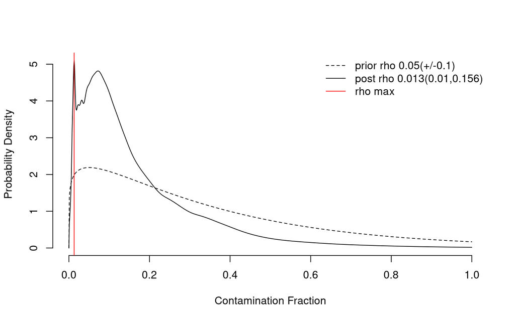

```r
# write output (generated already)
#DropletUtils:::write10xCounts("/workdir/yah6/soupx_WT2_filt", adj.counts, overwrite = T)
```